# Analysis and QC of SSI’s breakthrough data (Denmark)

Kristoffer T. Bæk , true  
2022-01-13

Every Tuesday since week 38, 2021, SSI has published datasets related to breakthrough infections. The data is given as Table 1 and Table 2, where Table 1 is not age stratified whereas Table 2 is. Table 2 is published as several csv files as shown below:

```r
lasttue <- last_wday_date(today(), 3) %>% date_to_yymmdd()

list.files(paste0("../data/SSIdata_", lasttue), pattern = "gennembrudsinfektioner_table2")
```

```
 [1] "gennembrudsinfektioner_table2_antal_cases.csv"
 [2] "gennembrudsinfektioner_table2_antal_dode.csv"
 [3] "gennembrudsinfektioner_table2_antal_indlagte.csv"
 [4] "gennembrudsinfektioner_table2_antal_intensiv.csv"
 [5] "gennembrudsinfektioner_table2_antal_repositive.csv"
 [6] "gennembrudsinfektioner_table2_antal_tests_notprevpos.csv"
 [7] "gennembrudsinfektioner_table2_antal_tests_total.csv"
 [8] "gennembrudsinfektioner_table2_antal_tests.csv"
 [9] "gennembrudsinfektioner_table2_incidence_alle.csv"
[10] "gennembrudsinfektioner_table2_incidence_cases.csv"
[11] "gennembrudsinfektioner_table2_incidence_dode.csv"
[12] "gennembrudsinfektioner_table2_incidence_indlagte.csv"
[13] "gennembrudsinfektioner_table2_incidence_intensiv.csv"
[14] "gennembrudsinfektioner_table2_incidence_tests.csv"
```

Furthermore, the numbers in the tables are stratified by vaccination status as follows:

- Ingen vaccination (no vaccination)
- Første vaccination (first dose, counts from day of dose)
- Anden vaccination (second or more doses, counts from day of second dose)
- Fuld effekt efter primært forløb (counts from 14 days after second dose up to 14 days after third dose, if relevant)
- Fuld effekt efter revaccination (counts from 14 days after third dose)

This means that ‘Ingen vaccination’, ‘Første vaccination’ and ‘Anden vaccination’ sums up to the total number (e.g. tests, cases etc.).

## Tidy the datasets

For convenience, I read all Table 2 files and combine them into one file. For each csv file, I rename the variables for better consistency by defining `Type` as either ‘antal’ (number) or ‘incidence’ (number per 100,000), and `Variable` as e.g. ‘cases’, ‘tests’ etc as given by the csv filename (for Table 2) or the variable name (for Table 1). Furthermore, I add a third identifier, `Group`, to indicate e.g previous infection status: ‘notprevpos’ (not previously positive), ‘prevpos’ (previously positive), or ‘alle’ (all). As an example, ‘antal_cases’ become ‘antal, cases, notprevpos’ (`Type, Variable, Group`), and ‘antal_repositive’ becomes ‘antal, cases, prevpos’ (`Type, Variable, Group`).

I recode Table 1 using the same system.

```r
# read and tidy table 1
read_csv2(paste0("../data/SSIdata_", lasttue, "/gennembrudsinfektioner_table1.csv")) %>%
  pivot_longer(-Ugenummer, names_to = c("Variable", "Vax_status"), values_to = "Value", names_sep = "_[A-Z]") %>%
  separate(Variable, c("Type", "Variable"), sep = "_", extra = "merge") %>%
  mutate(
    Variable = str_replace(Variable, "_", "."),
    # rename some SSI variables for better consistency
    Variable = case_when(
      Variable == "personer" ~ "personer.notprevpos",
      Variable == "cases" ~ "cases.notprevpos",
      Variable == "repositive" ~ "cases.prevpos",
      Variable == "tests" ~ "tests.alle",
      TRUE ~ Variable
    ),
    # fix loss of first letter caused by separation
    Vax_status = case_when(
      Vax_status == "ngen vaccination" ~ "Ingen vaccination",
      Vax_status == "ørste vaccination" ~ "Første vaccination",
      Vax_status == "nden vaccination" ~ "Anden vaccination",
      Vax_status == "uld effekt efter primært forløb" ~ "Fuld effekt efter primært forløb",
      Vax_status == "uld effekt efter revaccination" ~ "Fuld effekt efter revaccination",
    ),
    Week = as.integer(str_sub(Ugenummer, 5, 6)),
    Year = as.integer(str_sub(Ugenummer, 8, 11))
  ) %>%
  select(-Ugenummer) %>%
  separate(Variable, c("Variable", "Group"), "\\.") %>%
  select(Type, Variable, Group, Week, Year, everything()) %T>%
  write_csv2("../data/tidy_breakthru_table1.csv") %>%
  arrange(desc(Year), desc(Week)) %>%
  head(10) %>%
  kable(caption = "Example rows in cleaned up Table 1")
```

Table 1: Example rows in cleaned up Table 1

| Type | Variable | Group | Week | Year | Vax_status | Value |
| --- | --- | --- | --- | --- | --- | --- |
| antal | personer | alle | 1 | 2022 | Ingen vaccination | 1066643 |
| antal | personer | alle | 1 | 2022 | Første vaccination | 223948 |
| antal | personer | alle | 1 | 2022 | Anden vaccination | 4584197 |
| antal | personer | alle | 1 | 2022 | Fuld effekt efter primært forløb | 2349236 |
| antal | personer | alle | 1 | 2022 | Fuld effekt efter revaccination | 2173492 |
| antal | personer | notprevpos | 1 | 2022 | Ingen vaccination | 923675 |
| antal | personer | notprevpos | 1 | 2022 | Første vaccination | 194549 |
| antal | personer | notprevpos | 1 | 2022 | Anden vaccination | 4252790 |
| antal | personer | notprevpos | 1 | 2022 | Fuld effekt efter primært forløb | 2123149 |
| antal | personer | notprevpos | 1 | 2022 | Fuld effekt efter revaccination | 2075217 |

```r
# read and tidy table 2
read_tidy_table2 <- function(filename) {
  type <- str_split(filename, "_")[[1]][4]
  variable <- str_split(filename, paste0(type, "_"))[[1]][2] %>%
    str_sub(1, length(.) - 6)

  read_csv2(filename) %>%
    pivot_longer(-Aldersgruppe, names_to = c("Week", "Vax_status"), values_to = "Value", names_sep = "_") %>%
    mutate(
      Year = as.integer(str_sub(Week, 8, 11)),
      Week = as.integer(str_sub(Week, 5, 6))
    ) %>%
    # remove the two summarizing age categories
    filter(
      !Aldersgruppe %in% c("12+", "Alle")
    ) %>%
    mutate(
      Type = type,
      Variable = variable
    ) %>%
    mutate(
      Variable = str_replace(Variable, "_", "."),
      # rename some SSI variables for better consistency
      Variable = case_when(
        Variable == "tests" ~ "tests.alle",
        Variable == "cases" ~ "cases.notprevpos",
        Variable == "repositive" ~ "cases.prevpos",
        Variable == "alle" ~ "cases.alle",
        TRUE ~ Variable
      ),
    ) %>%
    separate(Variable, c("Variable", "Group"), "\\.") %>%
    rename(Age = Aldersgruppe) %>%
    select(Type, Variable, Group, Week, Year, everything())
}

list.files(paste0("../data/SSIdata_", lasttue), pattern = "gennembrudsinfektioner_table2", full.names = TRUE) %>%
  lapply(read_tidy_table2) %>%
  bind_rows() %T>%
  write_csv2("../data/tidy_breakthru_table2.csv") %>%
  arrange(desc(Year), desc(Week)) %>%
  head(10) %>%
  kable(caption = "Example rows in cleaned up Table 2")
```

Table 2: Example rows in cleaned up Table 2

| Type | Variable | Group | Week | Year | Age | Vax_status | Value |
| --- | --- | --- | --- | --- | --- | --- | --- |
| antal | cases | notprevpos | 1 | 2022 | 0-5 | Ingen vaccination | 7108 |
| antal | cases | notprevpos | 1 | 2022 | 0-5 | Første vaccination | 346 |
| antal | cases | notprevpos | 1 | 2022 | 0-5 | Anden vaccination | 52 |
| antal | cases | notprevpos | 1 | 2022 | 0-5 | Fuld effekt efter primært forløb | 1 |
| antal | cases | notprevpos | 1 | 2022 | 0-5 | Fuld effekt efter revaccination | 0 |
| antal | cases | notprevpos | 1 | 2022 | 6-11 | Ingen vaccination | 5211 |
| antal | cases | notprevpos | 1 | 2022 | 6-11 | Første vaccination | 2835 |
| antal | cases | notprevpos | 1 | 2022 | 6-11 | Anden vaccination | 1069 |
| antal | cases | notprevpos | 1 | 2022 | 6-11 | Fuld effekt efter primært forløb | 67 |
| antal | cases | notprevpos | 1 | 2022 | 6-11 | Fuld effekt efter revaccination | 0 |

```r
bt_1 <- read_csv2("../data/tidy_breakthru_table1.csv")
bt_2 <- read_csv2("../data/tidy_breakthru_table2.csv")
```

## Deduction of additional variables

Having tidied the datasets, I go on to deduce some missing variables. The already available variables in Table 1 and Table 2 are shown below:

Table 3: Variables available in Table 1

| Type | Variable | Group |
| --- | --- | --- |
| antal | personer | alle |
| antal | personer | notprevpos |
| antal | cases | notprevpos |
| antal | tests | alle |
| antal | tests | notprevpos |
| antal | tests | total |
| antal | cases | prevpos |
| antal | indlagte | NA |

Table 4: Variables available in Table 2

| Type | Variable | Group |
| --- | --- | --- |
| antal | cases | notprevpos |
| antal | dode | NA |
| antal | indlagte | NA |
| antal | intensiv | NA |
| antal | cases | prevpos |
| antal | tests | notprevpos |
| antal | tests | total |
| antal | tests | alle |
| incidence | cases | alle |
| incidence | cases | notprevpos |
| incidence | dode | NA |
| incidence | indlagte | NA |
| incidence | intensiv | NA |
| incidence | tests | alle |

For the variable ‘tests, total’ a person can count several times in a week (but only once per day), whereas for ‘tests, alle’ and ‘tests, notprevpos’, a person can count only once per week. ´Tests, total´ is not used in my analyses because it is less comparable to other variables, e.g incidences that are calculated using *person-weeks*.

I deduce missing variables as shown in the code below:

```r
bt_2_deduced <- read_csv2("../data/tidy_breakthru_table2.csv") %>%
  filter(Variable %in% c("cases", "tests")) %>%
  pivot_wider(names_from = c(Type, Variable, Group), values_from = Value, names_sep = "_") %>%
  select(-antal_tests_total) %>%
  mutate(
    antal_personer_alle = antal_tests_alle / incidence_tests_alle * 100000,
    antal_personer_notprevpos = antal_cases_notprevpos / incidence_cases_notprevpos * 100000,
    antal_personer_prevpos = antal_personer_alle - antal_personer_notprevpos,
    antal_tests_prevpos = antal_tests_alle - antal_tests_notprevpos,
    incidence_cases_prevpos = antal_cases_prevpos / antal_personer_prevpos * 100000,
    incidence_tests_prevpos = antal_tests_prevpos / antal_personer_prevpos * 100000,
    incidence_tests_notprevpos = antal_tests_notprevpos / antal_personer_notprevpos * 100000
  ) %>%
  mutate(
    across(matches("antal"), as.integer),
    across(matches("incidence"), round, 2))
```

And calculate the test adjusted incidenses:

```r
# function and beta value to calucate the test adjusted incidence
tai <- function(pop, pos, tests, beta) {
  pos / (pop * (tests / pop)**beta) * 100000
}

beta <- 0.5

bt_2_deduced %>%
  mutate(
    incidence_tac_notprevpos = tai(antal_personer_notprevpos, antal_cases_notprevpos, antal_tests_notprevpos, beta),
    incidence_tac_prevpos = tai(antal_personer_prevpos, antal_cases_prevpos, antal_tests_prevpos, beta)
  ) %>%
  pivot_longer(c(antal_cases_notprevpos:incidence_tac_prevpos), names_to = c("Type", "Variable", "Group"), values_to = "Value", names_sep = "_") %>%
  arrange(Age, Week, Year, Vax_status, Type, Variable, Group) %>%
  write_csv2("../data/tidy_breakthru_table2_deduced.csv")
```

## QC checks

### Table 1 vs Table 2

First I compare the deduced population sizes in Table 2 with the non-age-stratified population sizes in Table 1.

```r
bt_2_extra <- read_csv2("../data/tidy_breakthru_table2_deduced.csv")

bt_2_extra %>%
  filter(Type != "incidence") %>%
  group_by(Week, Year, Vax_status, Type, Variable, Group) %>%
  summarize(
    Table2 = sum(Value, na.rm = TRUE)
  ) %>%
  inner_join(filter(bt_1, Type == "antal" & Variable == "personer"), by = c("Week", "Year", "Type", "Variable", "Group", "Vax_status")) %>%
  rename(Table1 = Value) %>%
  mutate(
    Diff = Table2 - Table1,
    Diff_pct = round(abs(Diff / Table1) * 100, 2)
  ) %>%
  arrange(desc(Diff_pct)) %>%
  head(10) %>%
  kable(caption = "Percent difference between deduced population sizes in Table 2 vs Table 1, arranged high to low, first 10 rows")
```

Table 5: Percent difference between deduced population sizes in Table 2 vs Table 1, arranged high to low, first 10 rows

| Week | Year | Vax_status | Type | Variable | Group | Table2 | Table1 | Diff | Diff_pct |
| --- | --- | --- | --- | --- | --- | --- | --- | --- | --- |
| 38 | 2021 | Fuld effekt efter revaccination | antal | personer | notprevpos | 0 | 862 | -862 | 100.00 |
| 40 | 2021 | Fuld effekt efter revaccination | antal | personer | notprevpos | 28964 | 40079 | -11115 | 27.73 |
| 39 | 2021 | Fuld effekt efter revaccination | antal | personer | notprevpos | 9145 | 12030 | -2885 | 23.98 |
| 41 | 2021 | Første vaccination | antal | personer | notprevpos | 59570 | 61776 | -2206 | 3.57 |
| 42 | 2021 | Fuld effekt efter revaccination | antal | personer | notprevpos | 79242 | 81104 | -1862 | 2.30 |
| 38 | 2021 | Fuld effekt efter revaccination | antal | personer | alle | 903 | 915 | -12 | 1.31 |
| 41 | 2021 | Fuld effekt efter revaccination | antal | personer | notprevpos | 63471 | 64261 | -790 | 1.23 |
| 40 | 2021 | Første vaccination | antal | personer | notprevpos | 66540 | 67351 | -811 | 1.20 |
| 38 | 2021 | Første vaccination | antal | personer | notprevpos | 92882 | 93816 | -934 | 1.00 |
| 39 | 2021 | Fuld effekt efter revaccination | antal | personer | alle | 12584 | 12605 | -21 | 0.17 |

Then I compare the deduced population size for previously infected in Table 2 with the non-age-stratified population size for previously infected in Table 1.

```r
prevpos_check <- bt_2_extra %>%
  filter(Type != "incidence") %>%
  group_by(Week, Year, Vax_status, Type, Variable, Group) %>%
  summarize(
    Table2 = sum(Value, na.rm = TRUE)
  ) %>%
  inner_join(filter(bt_1, Type == "antal" & Variable == "personer"), by = c("Week", "Year", "Type", "Variable", "Group", "Vax_status")) %>%
  rename(Table1 = Value) %>%
  # pivot swap
  pivot_wider(names_from = c(Variable, Group), values_from = c(Table1, Table2), names_sep = "_") %>%
  pivot_longer(c(-Week, -Year, -Vax_status, -Type), names_to = c("Dataset", "Variable", "Group"), values_to = "value", names_sep = "_") %>%
  pivot_wider(names_from = c(Variable, Group), values_from = value, names_sep = "_") %>%
  mutate(
    personer_prevpos = personer_alle - personer_notprevpos
  ) %>%
  select(-personer_alle, -personer_notprevpos) %>%
  pivot_wider(names_from = Dataset, values_from = personer_prevpos) %>%
  mutate(
    Diff = Table2 - Table1,
    Diff_pct = round(abs(Diff / Table1) * 100, 2)
  )

prevpos_check %>%
  arrange(desc(Diff_pct)) %>%
  head(15) %>%
  kable(caption = "Percent difference between deduced prevpos population sizes in Table 2 vs Table 1, arranged high to low, first 15 rows")
```

Table 6: Percent difference between deduced prevpos population sizes in Table 2 vs Table 1, arranged high to low, first 15 rows

| Week | Year | Vax_status | Type | Table1 | Table2 | Diff | Diff_pct |
| --- | --- | --- | --- | --- | --- | --- | --- |
| 38 | 2021 | Fuld effekt efter revaccination | antal | 53 | 903 | 850 | 1603.77 |
| 40 | 2021 | Fuld effekt efter revaccination | antal | 2146 | 13257 | 11111 | 517.75 |
| 39 | 2021 | Fuld effekt efter revaccination | antal | 575 | 3439 | 2864 | 498.09 |
| 42 | 2021 | Fuld effekt efter revaccination | antal | 3953 | 5808 | 1855 | 46.93 |
| 41 | 2021 | Fuld effekt efter revaccination | antal | 3449 | 4233 | 784 | 22.73 |
| 41 | 2021 | Første vaccination | antal | 12778 | 14966 | 2188 | 17.12 |
| 40 | 2021 | Første vaccination | antal | 13469 | 14265 | 796 | 5.91 |
| 38 | 2021 | Første vaccination | antal | 16431 | 17349 | 918 | 5.59 |
| 44 | 2021 | Fuld effekt efter revaccination | antal | 6424 | 6681 | 257 | 4.00 |
| 43 | 2021 | Fuld effekt efter revaccination | antal | 4918 | 5040 | 122 | 2.48 |
| 38 | 2021 | Fuld effekt efter primært forløb | antal | 195006 | 191185 | -3821 | 1.96 |
| 38 | 2021 | Anden vaccination | antal | 203289 | 206251 | 2962 | 1.46 |
| 45 | 2021 | Fuld effekt efter revaccination | antal | 9858 | 9941 | 83 | 0.84 |
| 41 | 2021 | Anden vaccination | antal | 215325 | 214073 | -1252 | 0.58 |
| 39 | 2021 | Anden vaccination | antal | 208427 | 207369 | -1058 | 0.51 |

There are less than 10 very large relative differences, also in the early weeks for the boosted group. Apart from those, most of the differences are less than 1%.

### Table 2 vs population sizes from Danmarks Statistik

Then I compare the deduced age-stratified population sizes in Table 2 with population data from DST.

```r
bt_age_breaks <- c(-1, 5, 11, 15, 19, 29, 39, 49, 59, 64, 69, 79, 125)

pop <- read_tidy_age(bt_age_breaks) %>%
  group_by(Year, Quarter, Age) %>%
  summarize(Population = sum(Population, na.rm = TRUE))

bt_2_extra %>%
  filter(
    Type == "antal",
    Variable == "personer",
    Group == "alle",
    Vax_status %in% c("Ingen vaccination", "Første vaccination", "Anden vaccination")
    ) %>%
  group_by(Age, Week, Year) %>%
  summarize(
    Table2 = sum(Value, na.rm = TRUE)
  ) %>%
  mutate(
    Date = as.Date(paste0(Year, sprintf("%02d", Week), "1"), "%Y%U%u"),
    Quarter = quarter(Date)
    ) %>%
  left_join(pop, by = c("Age", "Year", "Quarter")) %>%
  arrange(Date) %>%
  group_by(Age) %>%
  fill(Population) %>%
  mutate(
    Diff = Table2 - Population,
    Diff_pct = round(abs(Diff / Table2) * 100, 2)
  ) %>%
  arrange(desc(Diff_pct)) %>%
  select(-Date) %>%
  head(10) %>%
  kable(caption = "Percent difference between deduced total population sizes in Table 2 vs population sizes from DST, arranged high to low, first 10 rows")
```

Table 7: Percent difference between deduced total population sizes in Table 2 vs population sizes from DST, arranged high to low, first 10 rows

| Age | Week | Year | Table2 | Quarter | Population | Diff | Diff_pct |
| --- | --- | --- | --- | --- | --- | --- | --- |
| 0-5 | 49 | 2021 | 388770 | 4 | 373427 | 15343 | 3.95 |
| 0-5 | 50 | 2021 | 388635 | 4 | 373427 | 15208 | 3.91 |
| 0-5 | 48 | 2021 | 387883 | 4 | 373427 | 14456 | 3.73 |
| 12-15 | 1 | 2022 | 283152 | 1 | 272988 | 10164 | 3.59 |
| 0-5 | 51 | 2021 | 386954 | 4 | 373427 | 13527 | 3.50 |
| 0-5 | 47 | 2021 | 386920 | 4 | 373427 | 13493 | 3.49 |
| 0-5 | 52 | 2021 | 386840 | 4 | 373427 | 13413 | 3.47 |
| 12-15 | 52 | 2021 | 282606 | 4 | 272988 | 9618 | 3.40 |
| 0-5 | 1 | 2022 | 386425 | 1 | 373427 | 12998 | 3.36 |
| 12-15 | 51 | 2021 | 282256 | 4 | 272988 | 9268 | 3.28 |

### Table 2 vs daily case numbers from SSI

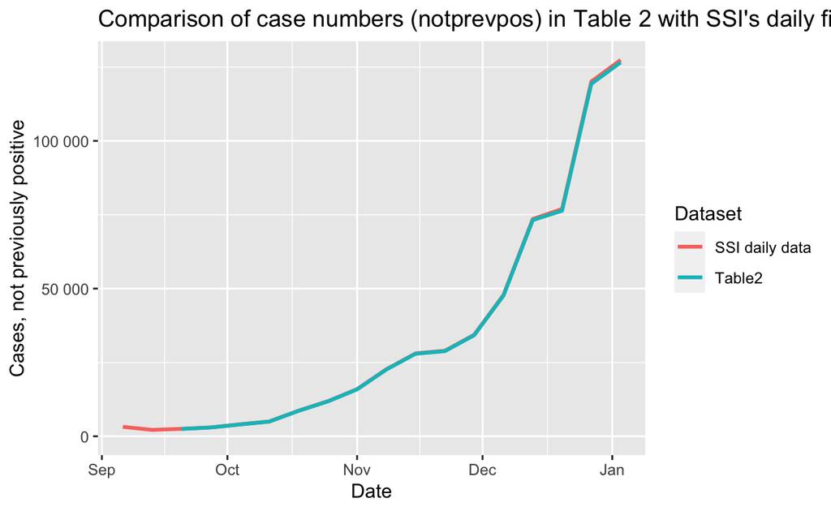

```r
temp_df <- bt_2_extra %>%
  filter(
    Type == "antal",
    Variable == "cases",
    Group == "notprevpos",
    Vax_status %in% c("Ingen vaccination", "Første vaccination", "Anden vaccination")
    ) %>%
  mutate(Date = as.Date(paste0(Year, sprintf("%02d", Week), "1"), "%Y%U%u")) %>%
  group_by(Date) %>%
  summarize(Table2 = sum(Value, na.rm = TRUE))


read_csv2("../data/SSI_daily_data.csv") %>%
  filter(name == "Positive") %>%
  select(Date, daily) %>%
  group_by(Date = floor_date(Date, unit = "week", week_start = getOption("lubridate.week.start", 1))) %>%
  filter(!is.na(daily)) %>%
  mutate(n = n()) %>%
  filter(n == 7) %>%
  summarize(`SSI daily data` = sum(daily, na.rm = TRUE)) %>%
  full_join(temp_df, by = "Date") %>%
  pivot_longer(-Date) %>%
  filter(Date > ymd("2021-09-01")) %>%
  ggplot() +
  geom_line(aes(Date, value, color = name), size = 1) +
  scale_color_discrete(name = "Dataset") +
  scale_y_continuous(limits = c(0, NA), labels = scales::number) +
  labs(
    y = "Cases, not previously positive",
    title = "Comparison of case numbers (notprevpos) in Table 2 with SSI's daily files"
  )
```

As expected there is a very good fit between the weekly case numbers in Table 2 and SSI’s daily case numbers.

### Number of previosly infected vs cumulated case numbers from SSI up to 60 or 30 days ago

Previosly infected in Table 1 and Table 2 is defined as a person whose last positive test was >60 days ago. Therefore the deduced number of previosly infected in the breakthrough files should correspond to the number of cases up to 60 days ago.

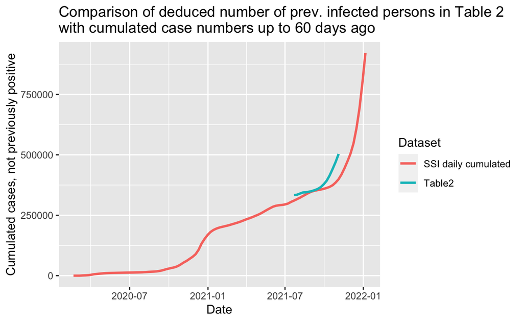

```r
temp_df <- prevpos_check %>%
  filter(Vax_status %in% c("Ingen vaccination", "Første vaccination", "Anden vaccination")) %>%
  group_by(Week, Year) %>%
  summarize(Table2 = sum(Table2, na.rm = TRUE)) %>%
  mutate(Date = as.Date(paste0(Year, sprintf("%02d", Week), "1"), "%Y%U%u"))

read_csv2("../data/SSI_daily_data.csv") %>%
  filter(name == "Positive") %>%
  select(Date, daily) %>%
  mutate(`SSI daily cumulated` = cumsum(daily)) %>%
  full_join(temp_df, by = "Date") %>%
  mutate(Table2 = lead(Table2, 60)) %>%
  select(-Week, -Year, -daily) %>%
  filter(wday(Date) == 5) %>%
  pivot_longer(-Date) %>%
  ggplot() +
  scale_color_discrete(name = "Dataset") +
  geom_line(aes(Date, value, color = name), size = 1) +
  scale_y_continuous(limits = c(0, NA)) +
  labs(
    y = "Cumulated cases, not previously positive",
    title = "Comparison of deduced number of prev. infected persons in Table 2\nwith cumulated case numbers up to 60 days ago"
  )
```

There is not a good fit. I try comparing with the number of cases up to 30 days ago instead.

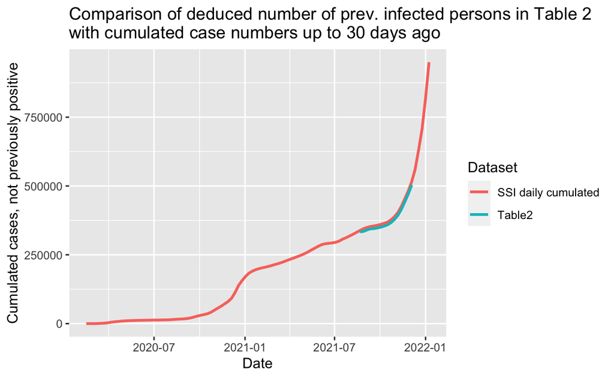

```r
read_csv2("../data/SSI_daily_data.csv") %>%
  filter(name == "Positive") %>%
  select(Date, daily) %>%
  mutate(`SSI daily cumulated` = cumsum(daily)) %>%
  full_join(temp_df, by = "Date") %>%
  mutate(Table2 = lead(Table2, 30)) %>%
  select(-Week, -Year, -daily) %>%
  filter(wday(Date) == 7) %>%
  pivot_longer(-Date) %>%
  ggplot() +
  scale_color_discrete(name = "Dataset") +
  geom_line(aes(Date, value, color = name), size = 1) +
  scale_y_continuous(limits = c(0, NA)) +
  labs(
    y = "Cumulated cases, not previously positive",
    title = "Comparison of deduced number of prev. infected persons in Table 2\nwith cumulated case numbers up to 30 days ago"
  )
```

This fits much better, which I don’t understand.

I try the same with the numbers for previously infected from Table 1. This is just to be absolutely sure given that I already know that these numbers match between Table 1 and 2.

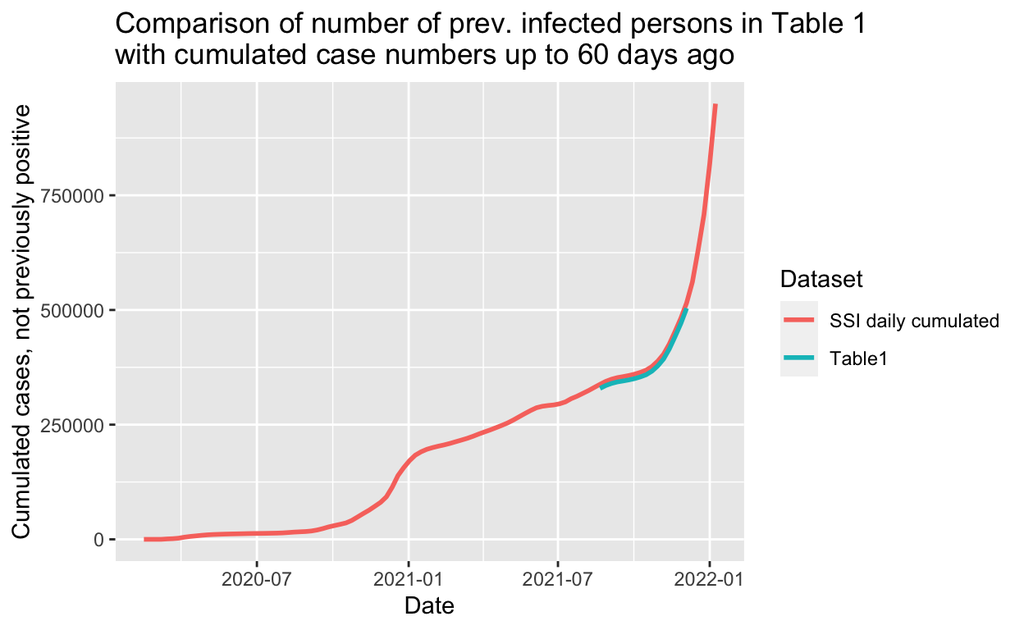

```r
temp_df <- bt_1 %>%
  filter(
    Vax_status %in% c("Ingen vaccination", "Første vaccination", "Anden vaccination"),
    Type == "antal",
    Variable == "personer"
    ) %>%
  group_by(Week, Year, Group) %>%
  summarize(Value = sum(Value, na.rm = TRUE)) %>%
  pivot_wider(names_from = Group, values_from = Value) %>%
  mutate(
    Table1 = alle - notprevpos
  )  %>%
  mutate(Date = as.Date(paste0(Year, sprintf("%02d", Week), "1"), "%Y%U%u")) %>%
  select(-alle, -notprevpos)

read_csv2("../data/SSI_daily_data.csv") %>%
  filter(name == "Positive") %>%
  select(Date, daily) %>%
  mutate(`SSI daily cumulated` = cumsum(daily)) %>%
  full_join(temp_df, by = "Date") %>%
  mutate(Table1 = lead(Table1, 30)) %>%
  select(-Week, -Year, -daily) %>%
  filter(wday(Date) == 7) %>%
  pivot_longer(-Date) %>%
  ggplot() +
  scale_color_discrete(name = "Dataset") +
  geom_line(aes(Date, value, color = name), size = 1) +
  scale_y_continuous(limits = c(0, NA)) +
  labs(
    y = "Cumulated cases, not previously positive",
    title = "Comparison of number of prev. infected persons in Table 1\nwith cumulated case numbers up to 60 days ago"
  )
```

I get the same result as for the Table 2 numbers, as expected. But I still don’t understand it.